# **Student performance**

guilinXue

2020/6/13

###Introduction Hi Friends, welcome to my kernel! I have used dplyr and ggplot2 to manipulate and visualise the student performance data. I have then created a random forest to create a simple prediction model. If you find this script useful, please upvote or leave a comment with your feedback, Thanks!

### Loading data and libraries

key libraries used include:

ggplot2 - Data visualisation

dplyr - Data manipulation

kableExtra, xtable - Creating tables

RColorBrewer - Using colours

```
>
> Data <- read.csv("StudentsPerformance.csv", header = TRUE)
> library(kableExtra)
> library(xtable)
> library(RColorBrewer)
> library(ggplot2)
> library(dplyr)
> library(tidyr)
```

### Understanding the data

The data has eight variables and 1000 observations. The key variables include gender, race/ethnicity, parental level of education,lunch, test preparation course, math score, reading score and writing score.

```
> str(Data)
  'data.frame': 1000 obs. of  8 variables:
   $ gender                     : chr  "female" "female" "female" "male" ...
   $ race.ethnicity             : chr  "group B" "group C" "group B" "group A" ...
   $ parental.level.of.education: chr  "bachelor's degree" "some college" "master's degree" "associate's degree" ...
   $ lunch                      : chr  "standard" "standard" "standard" "free/reduced" ...
   $ test.preparation.course    : chr  "none" "completed" "none" "none" ...
   $ math.score                 : int  72 69 90 47 76 71 88 40 64 38 ...
   $ reading.score              : int  72 90 95 57 78 83 95 43 64 60 ...
   $ writing.score              : int  74 88 93 44 75 78 92 39 67 50 ...
```

### Exploratory data analysis

1. *Students By gender*: There are more 518 female students and 482 male students.

```
> plot1 <- ggplot() + geom_bar(data = Data, aes(x = Data$gender), width = 0.2, fill = "green") +
+     geom_text(stat = "count", data = Data, aes(x = Data$gender, label = ..count..),
+         vjust = -0.2) + theme_bw() + xlab("Gender") + ylab("Number of Students") +
+     theme_classic() + ggtitle("Number of Students by Gender") + scale_fill_brewer(type = "qual",
+     palette = 1, direction = 1, aesthetics = "fill") + ylim(0, 600)
>
> plot1
```

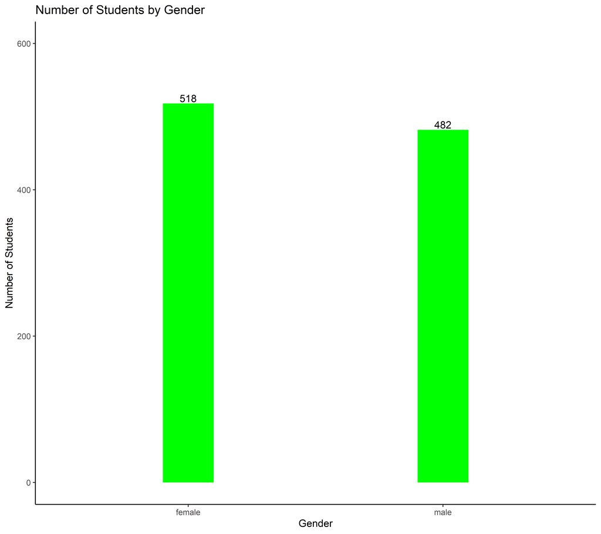

2. *Students By race*: There are 319 students in group C, 262 students in group D while there are only 89 students in group A.

```
> plot2 <- ggplot() + geom_bar(data = Data, aes(x = Data$race.ethnicity), width = 0.6,
+     fill = "green") + geom_text(data = Data, aes(x = Data$race.ethnicity, label = ..count..),
+     stat = "count", vjust = -0.2) + theme_bw() + xlab("Race/Ethnicity") + ylab("Number of Students") +
+     theme(text = element_text(family = "Tahoma")) + theme_classic() + scale_fill_brewer(type = "qual",
+     palette = 1, direction = 1, aesthetics = "fill") + ggtitle("Number of Students by Race/Ethnicity")
> plot2
```

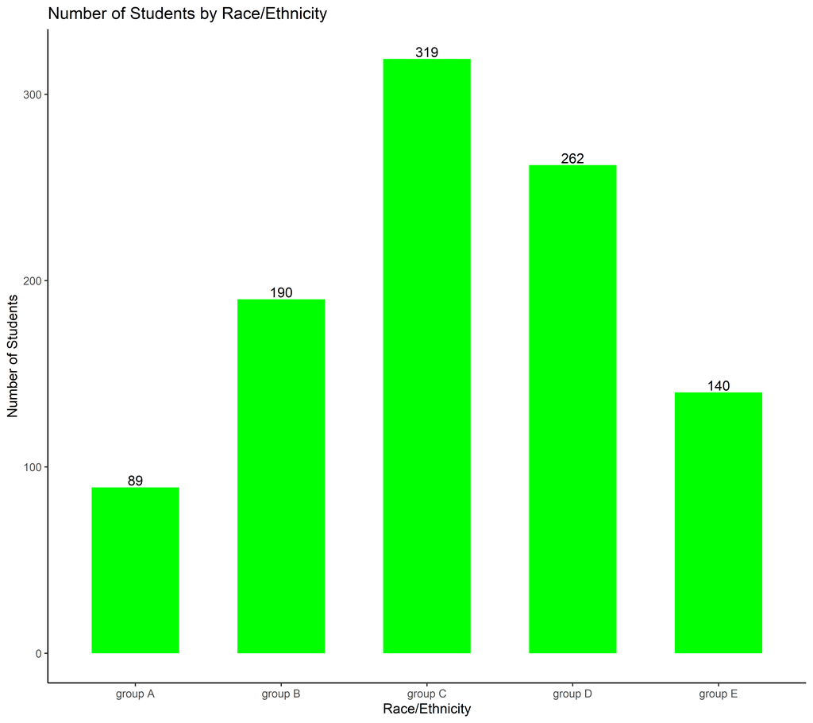

3. *Distribution of scores* 152 students scored between 65 - 70 marks in maths. 154 students scored in the same bracket in writing. 148 students scored between 70 - 75 marks in reading.

```
> Data_gather <- Data %>% mutate(StudentID = row_number()) %>% gather(key = "subject",
+     value = "score", math.score:writing.score)
>
> Data_gather %>% ggplot(aes(x = score)) + geom_histogram(bins = 20, colour = "green",
+     fill = "white") + facet_grid(subject ~ .) + theme_bw() + theme_classic() + scale_x_continuous(limits = c(0,
+     100), breaks = seq(0, 100, 10)) + # geom_label(aes(label = ..count..), stat = 'count', y = 150, size = 2) +
+ stat_bin(bins = 20, geom = "text", aes(label = ..count..), vjust = -1) + ylim(0,
+     200)
```

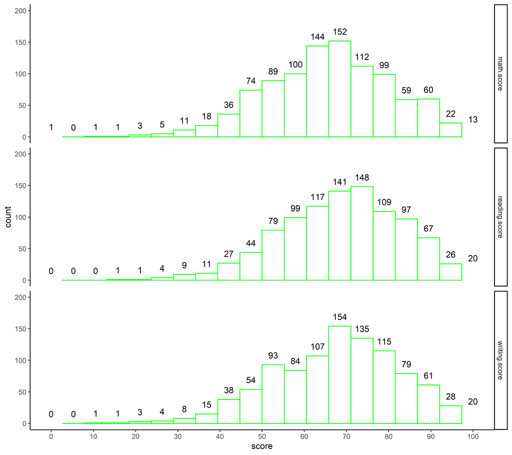

### Preparation courses

1. *Completion*: Majority of students do not complete preparation courses. Proportion of students completing preparation course is highest in group E.

```
> plot3 <- ggplot() + geom_bar(data = Data, aes(x = Data$test.preparation.course),
+     width = 0.6, fill = "green") + geom_text(data = Data, aes(x = Data$test.preparation.course,
+     label = ..count..), stat = "count", vjust = -0.2) + # geom_bar(data = Data, aes(x = Data$test.preparation.course, y =
+ # race.ethnicity), fill = '#bcd4e6', width = 0.6) +
+ facet_grid(. ~ race.ethnicity) + theme_bw() + xlab("Preparation course") + ylab("Number of Students") +
+     theme(text = element_text(family = "Tahoma")) + theme_classic() + ggtitle("Number of Students who completed Preparation course by Race/Ethnicity") +
+     scale_fill_brewer(type = "qual", palette = 1, direction = 1, aesthetics = "fill")
>
> plot3
```

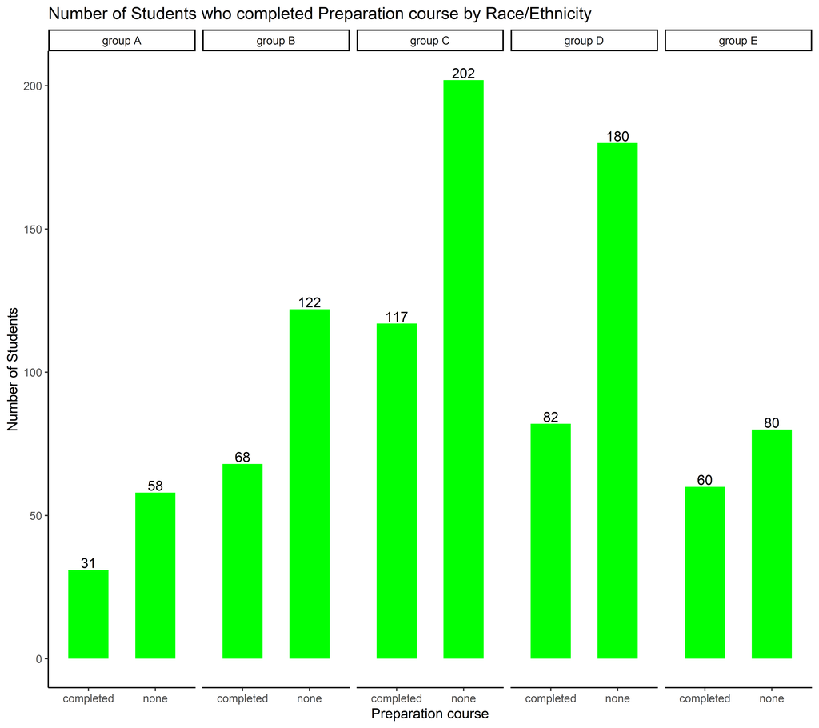

2. **Impact of course**: As we see the that the average of the scores of students who completed preparation course is higher than the average of scores of the students who did not complete the course.

```
> plot4 <- ggplot(data = Data_gather, aes(x = Data_gather$test.preparation.course,
+     y = Data_gather$score, fill = Data_gather$test.preparation.course)) + geom_boxplot() +
+     stat_summary(fun.y = mean, colour = "darkred", geom = "point", shape = 18, size = 3,
+         show_guide = FALSE) + theme_bw() + theme_classic() + xlab("Preparation Course") +
+     ylab("Average Score") + theme(text = element_text(family = "Tahoma"), legend.title = element_blank()) +
+     scale_fill_brewer(type = "qual", palette = 1, direction = 1, aesthetics = "fill")
>
> plot4
```

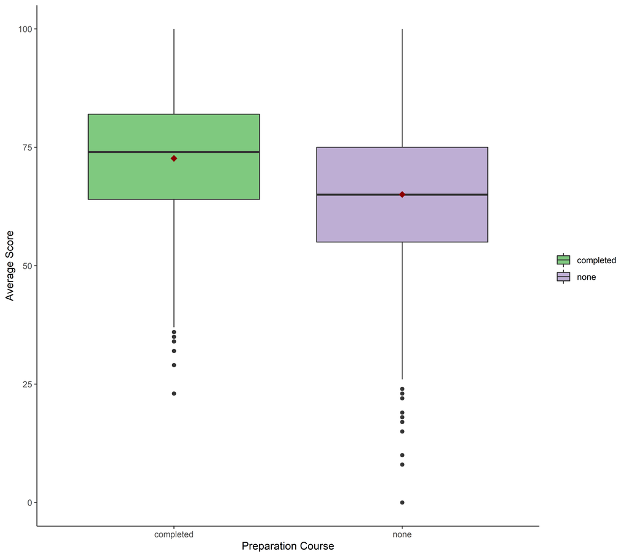

### Scores by race/ethnicity

Average scores are highest in the group E.

```
> plot5 <- ggplot(data = Data_gather, aes(x = Data_gather$race.ethnicity, y = Data_gather$score,
+     fill = Data_gather$race.ethnicity)) + geom_boxplot() + theme(text = element_text(family = "Tahoma"),
+     axis.text.x = element_blank(), legend.title = element_blank()) +
+ stat_summary(fun.y = mean, colour = "darkred", geom = "point", shape = 18, size = 3,
+     show_guide = FALSE) + facet_grid(. ~ subject) + theme_bw() + theme_classic() +
+     scale_fill_brewer(type = "qual", palette = 1, direction = 1, aesthetics = "fill") +
+     xlab("Race/ethnicity") + ylab("Score")
>
> plot5
```

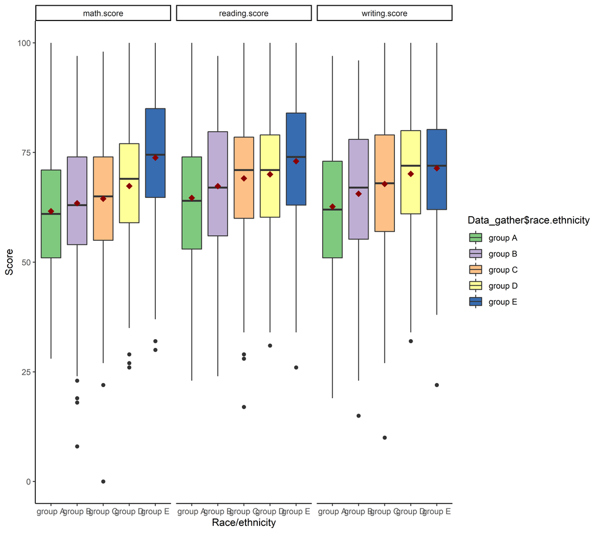

### Scores By gender

Female students have high average scores in reading and writing, while male students fare better in maths.

```
>
> plot6 <- ggplot(data = Data_gather, aes(x = Data_gather$gender, y = Data_gather$score,
+     fill = Data_gather$gender)) + geom_boxplot() + stat_summary(fun.y = mean, colour = "darkred",
+     geom = "point", shape = 18, size = 3, show_guide = FALSE) + facet_grid(. ~ subject) +
+     theme_bw() + theme_classic() + theme(legend.title = element_blank()) + xlab("Gender") +
+     ylab("Score") + scale_fill_brewer(type = "qual", palette = 1, direction = 1,
+     aesthetics = "fill")
>
> plot6
```

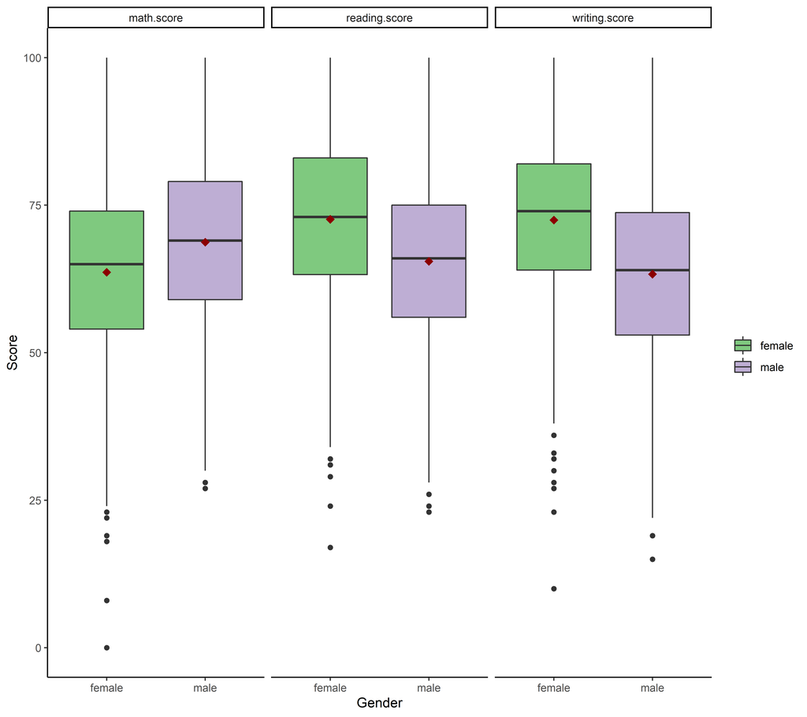

### Impact of the type of lunch

```
> Data_gather_mean <- Data_gather %>% group_by(StudentID) %>% summarise(mean = mean(score))
>
>
> table1 <- merge(Data_gather_mean, Data_gather[, c(1:6)], by = "StudentID") %>% distinct(StudentID,
+     .keep_all = TRUE) %>% group_by(race.ethnicity, lunch) %>% summarise(avg.score = mean(mean,
+     na.rm = TRUE))
>
> kable(table1)
```

| race.ethnicity | lunch | avg.score |
| --- | --- | --- |
| group A | free/reduced | 57.65741 |
| group A | standard | 66.61635 |
| group B | free/reduced | 60.97585 |
| group B | standard | 68.03030 |
| group C | free/reduced | 60.41228 |
| group C | standard | 70.86829 |
| group D | free/reduced | 64.66667 |
| group D | standard | 71.74651 |
| group E | free/reduced | 67.49594 |
| group E | standard | 74.92929 |

### Correlation between reading and writing score

There is a strong correlation between reading scores and the writing scores with a coefficient of 0.95.

```
> ggplot() + geom_point(data = Data, aes(x = Data$math.score, y = Data$reading.score)) +
+     theme_bw() + theme_classic() + xlab("Math Score") + ylab("Reading Score")
```

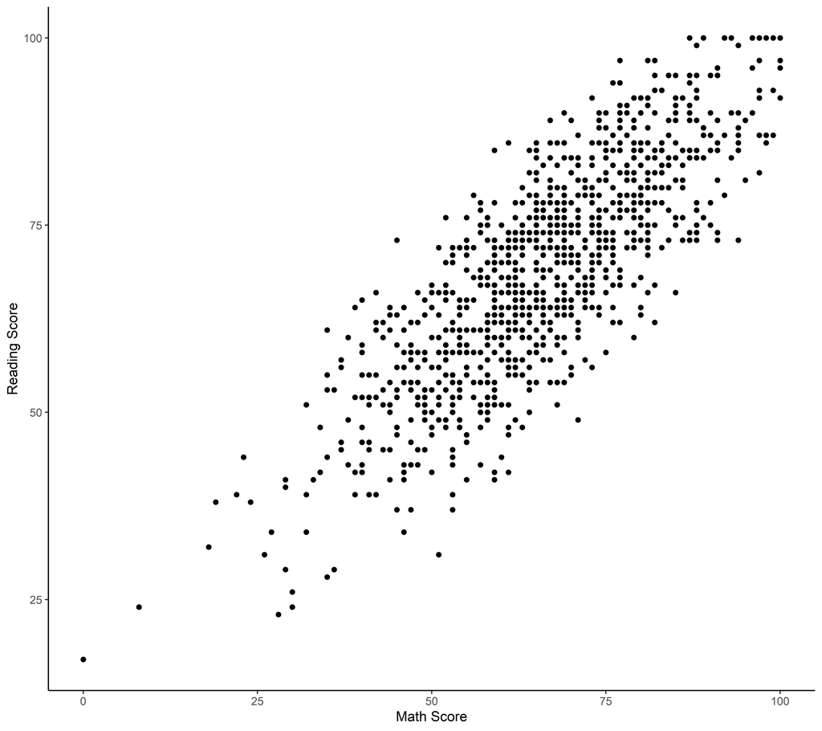

```
>
> ggplot() + geom_point(data = Data, aes(x = Data$writing.score, y = Data$reading.score)) +
+     theme_bw() + theme_classic() + xlab("Writing Score") + ylab("Reading Score")
```

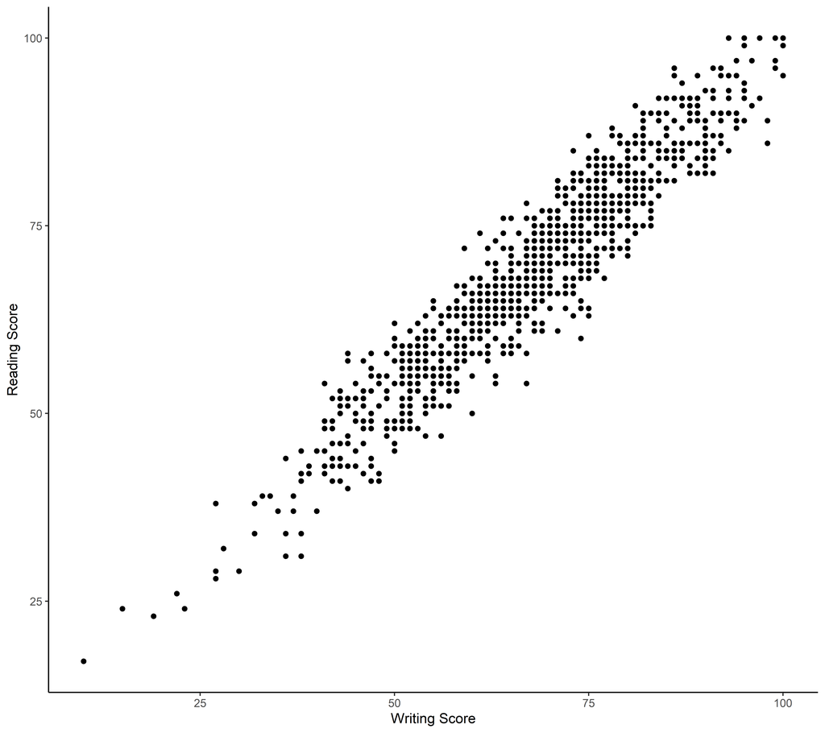

```
>
> cor.test(Data$math.score, Data$reading.score)

    Pearson's product-moment correlation

  data:  Data$math.score and Data$reading.score
  t = 44.855, df = 998, p-value < 2.2e-16
  alternative hypothesis: true correlation is not equal to 0
  95 percent confidence interval:
   0.7959276 0.8371428
  sample estimates:
        cor
  0.8175797
```

```
> cor.test(Data$math.score, Data$writing.score)

    Pearson's product-moment correlation

  data:  Data$math.score and Data$writing.score
  t = 42.511, df = 998, p-value < 2.2e-16
  alternative hypothesis: true correlation is not equal to 0
  95 percent confidence interval:
   0.7794321 0.8236517
  sample estimates:
       cor
  0.802642
```

```
> cor.test(Data$writing.score, Data$reading.score)

    Pearson's product-moment correlation

  data:  Data$writing.score and Data$reading.score
  t = 101.23, df = 998, p-value < 2.2e-16
  alternative hypothesis: true correlation is not equal to 0
  95 percent confidence interval:
   0.9487506 0.9597921
  sample estimates:
        cor
  0.9545981
```

### Prediction

We created a simple prediction model, to see if we predict whether the student had a test preparation course or not based on all other variables.

```
> library(randomForest)
> library(caret)
> Data1 <- Data
>
> Data1$gender <- as.numeric(factor(Data1$gender, levels = unique(Data1$gender)))
> Data1$race.ethnicity <- as.numeric(factor(Data1$race.ethnicity, levels = unique(Data1$race.ethnicity)))
> Data1$parental.level.of.education <- as.numeric(factor(Data1$parental.level.of.education,
+     levels = unique(Data1$parental.level.of.education)))
> Data1$lunch <- as.numeric(factor(Data1$lunch, levels = unique(Data1$lunch)))
> Data1$test.preparation.course <- as.numeric(factor(Data1$test.preparation.course,
+     levels = unique(Data1$test.preparation.course)))
> Data1$test.preparation.course = as.factor(Data1$test.preparation.course)
```

Let’s divide the set into training and test set with 70% of the records in the training set and the remaining in the test set.

```
> set.seed(125)
> train <- sample(nrow(Data1), 0.7 * nrow(Data1), replace = FALSE)
>
> TrainingSet <- Data1[train, ]
> TestSet <- Data1[-train, ]
>
> str(TrainingSet)
  'data.frame': 700 obs. of  8 variables:
   $ gender                     : num  1 2 1 1 1 2 1 2 2 1 ...
   $ race.ethnicity             : num  5 3 5 2 4 1 2 4 2 4 ...
   $ parental.level.of.education: num  4 4 4 4 2 5 1 5 5 6 ...
   $ lunch                      : num  2 2 1 1 2 1 1 1 2 2 ...
   $ test.preparation.course    : Factor w/ 2 levels "1","2": 1 2 1 1 1 1 2 1 1 2 ...
   $ math.score                 : int  70 79 66 66 60 82 79 76 59 35 ...
   $ reading.score              : int  84 82 65 77 66 82 92 73 53 55 ...
   $ writing.score              : int  81 82 69 73 70 80 89 68 52 60 ...
```

```
> str(TestSet)
  'data.frame': 300 obs. of  8 variables:
   $ gender                     : num  1 1 1 2 2 2 1 1 2 1 ...
   $ race.ethnicity             : num  2 1 1 4 3 2 2 1 4 2 ...
   $ parental.level.of.education: num  2 3 4 4 2 5 4 2 1 1 ...
   $ lunch                      : num  1 1 1 1 1 1 2 2 2 1 ...
   $ test.preparation.course    : Factor w/ 2 levels "1","2": 2 1 1 1 2 1 1 2 2 1 ...
   $ math.score                 : int  69 90 71 40 78 88 54 65 74 67 ...
   $ reading.score              : int  90 95 83 52 72 89 58 75 71 69 ...
   $ writing.score              : int  88 93 78 43 70 86 61 70 80 75 ...
```

```
> model1 <- randomForest(test.preparation.course ~ ., data = TrainingSet, importance = TRUE,
+     ntree = 500, mtry = 6)
> model1

  Call:
   randomForest(formula = test.preparation.course ~ ., data = TrainingSet,      importance = TRUE, ntree = 500, mtry = 6)
                 Type of random forest: classification
                       Number of trees: 500
  No. of variables tried at each split: 6

          OOB estimate of  error rate: 34.29%
  Confusion matrix:
      1   2 class.error
  1 358  87   0.1955056
  2 153 102   0.6000000
```

```
>
> importance(model1)
                                       1         2 MeanDecreaseAccuracy
  gender                      17.7840672 -2.721711            13.196305
  race.ethnicity              -0.8112868 -3.170055            -2.806145
  parental.level.of.education  1.8240109 -3.636623            -1.006550
  lunch                       -3.4390150 -3.219256            -4.845206
  math.score                  20.3995452 -7.679513            14.448533
  reading.score                7.3362333  2.656154             9.781532
  writing.score               32.5766861 19.313703            45.971698
                              MeanDecreaseGini
  gender                             14.291903
  race.ethnicity                     27.135167
  parental.level.of.education        32.758530
  lunch                               9.954324
  math.score                         77.101391
  reading.score                      70.516660
  writing.score                      91.115312
```

```
> varImpPlot(model1)
```

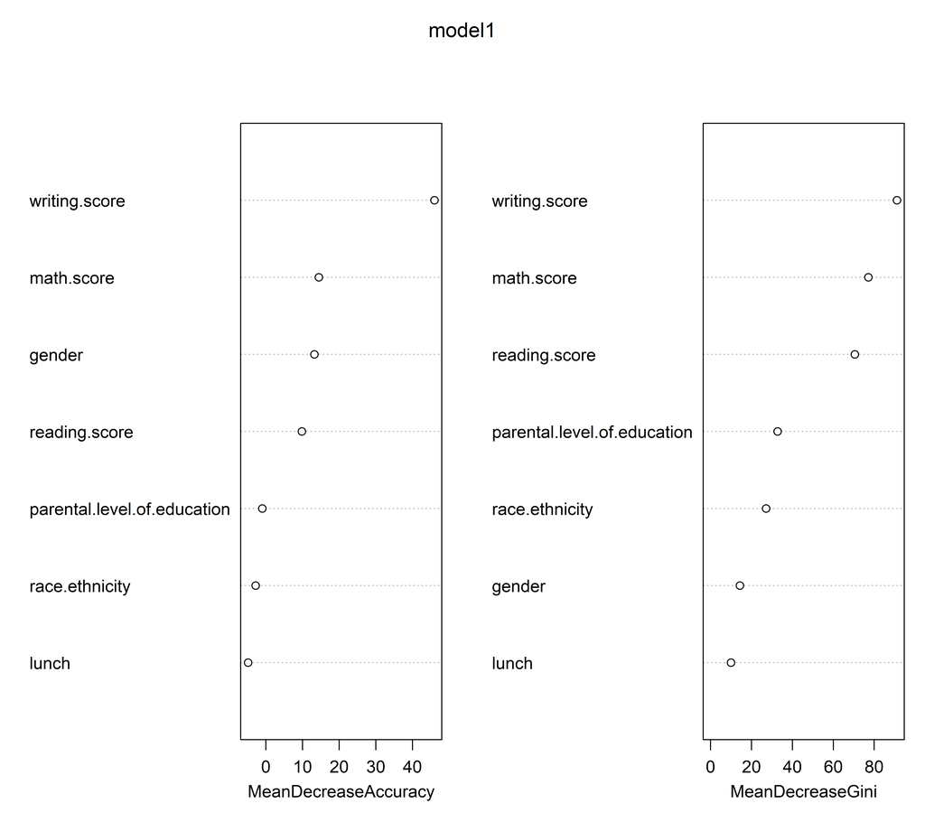

```
>
> PredTest <- predict(model1, TestSet, type = "class")
> mean(PredTest == TestSet$test.preparation.course)
  [1] 0.7266667
```

If you got to this point, then don’t forget to leave a comment. Thanks!